# ΜΙΣΤΑ002: Chi-square test of independence

## Chi-square test of independence

Chi-square test of independence is used to determine whether there is a significant association between two categorical variables. An association exists between two categorical variables if the distribution of one variable varies according to the value of the other. When we want to examine the **association** between two categorical variables we tabulate one against the other. This is called a **two-way table** (also known as a cross-tabulation).

**Assumptions**

- Independent observations
- Each individual is represented only once in the study. The rows (and columns) of the table are mutually exclusive, implying that each individual can belong in only one row and only one column.
- Large expected frequencies. The chi-square test is based on an approximation that works best when the expected frequencies are fairly large. No expected frequency should be less than 1 and no more than 20% of the expected frequencies should be less than 5 (Cochran's rule). (**Note:** Cochran's rule may be too conservative)

**Steps for conducting the test**

**Step 1. Define the null and alternative hypotheses under study**

**H<sub>0</sub>**: Τhere is no association between the two categorical variables (they are independent)

**H<sub>1</sub>**: Τhere is association between the two categorical variables (they are dependent)

**Step 2. Calculate the value of the test statistic specific to H<sub>0</sub>**

The data for chi-square tests are summarized using cross-tabulations tables of one categorical variable versus another. These tables are sometimes called frequency or contingency tables. It is usual to enter the explanatory variable in the rows, the outcome in the columns and using row percentages.

There are two sets of frequencies with which we are concerned, observed frequencies and expected frequencies. The observed frequencies (O) are the number of subjects or objects in our sample that fall into the various categories of the variable of interest. Expected frequencies (E) are the number of subjects or objects in our sample that we would expect to observe if some null hypothesis about the variable is true. Each expected frequency is the product of the two relevant marginal totals divided by the overall total.

**a) *rxc* contingency tables**

The general r×c (r: number of rows, c: number of columns) contingency table with the observed frequencies (O<sub>ij</sub>) is as follows:

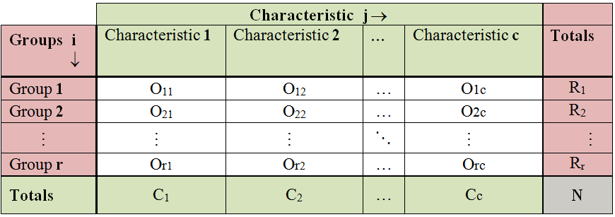

where  
i: the index for the row (i=1,2,...,r)  
j: the index for the column (j=1,2,...,c)  
R<sub>i</sub>: the total number of counts in the ith row (row marginal total)  
C<sub>j</sub>: the total number of counts in the jth column (column marginal total)  
N: the total sample size  
The table of expected values (E<sub>ij</sub>) corresponding to the observed data is:

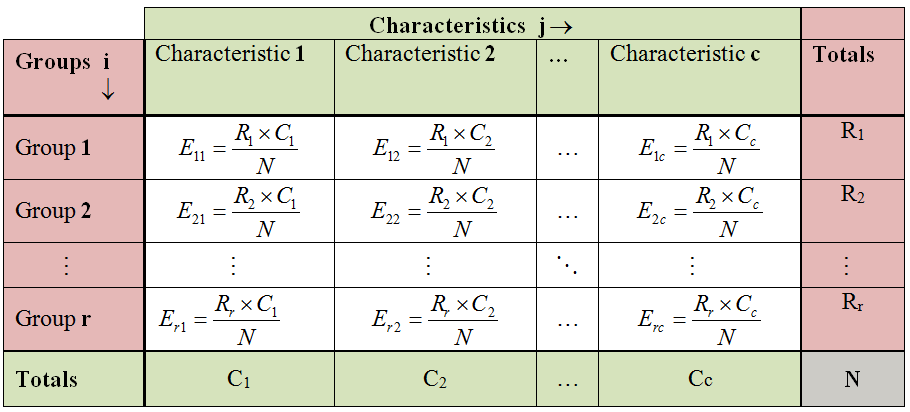

**Degrees of freedom:** df = (r − 1) × (c − 1).

**b) *2x2* contingency tables**

The simplest contingency table is a 2x2.

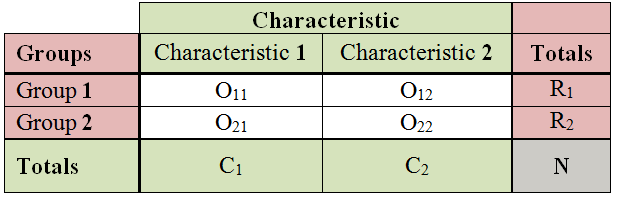

The **degrees of freedom** are df = (2− 1) × (2 − 1)=1.  
**On Yates’ continuity correction**

**Step 3. Compare the value of the test statistic to values from the χ<sup>2</sup>-distribution**

**Step 4. Interpretation**

Interpretation of the results.

**Worked Example**

[figure not shown]

Consider the following results from an influenza vaccine trial carried out during an epidemic. Of 460 adults who took part, 240 received influenza vaccination and 220 placebo vaccination. Overall 100 people contracted influenza, of whom 20 were in the vaccine group and 80 in the placebo group. We wish to assess the strength of the evidence that vaccination affected the probability of contracting influenza (a=0.05).

The cross-tabulation table below shows that the two variables each have two levels to create a 2×2 table with four cells.

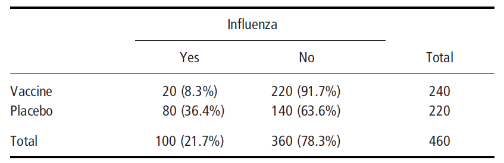

The table shows that the percentage contracting influenza was much lower in the vaccine group (8.3%), than in the placebo group (36.4%).

**Step 1. Define the null and alternative hypotheses under study**

**H<sub>0</sub>**: Τhere is no association between the influenza vaccine and the contraction of influenza.

**H<sub>1</sub>**: Τhere is association between the influenza vaccine and the contraction of influenza.

**Step 2. Calculate the value of the test statistic specific to H<sub>0</sub>**

The chi-squared test compares the observed numbers in each of the four categories in the contingency table with the numbers to be expected if there were no difference in efficacy between the vaccine and placebo. Overall 100/460 people contracted influenza and, if the vaccine and the placebo were equally effective, one would expect this same proportion in each of the two groups; that is E<sub>11</sub>=240x100/460=52.2 in the vaccine group and E<sub>21</sub>=220x100/460=47.8 in the placebo group would have contracted influenza. Similarly E<sub>12</sub>=240x360/460=187.8 and E<sub>22</sub>=220x360/460=172.2 would have escaped influenza. These expected numbers are shown in the following table with the expected values (E<sub>ij</sub>) :

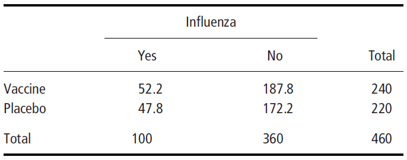

Now, the chi-square statistic can be calculated:

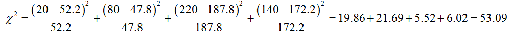

or using the shortcut formula

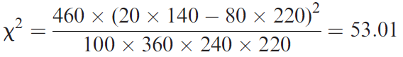

which, apart from rounding error, is the same as the above obtained value.

**Step 3. Compare the value of the test statistic to values from the** **χ<sup>2</sup>-****distribution**  
The critical value of chi-square distribution for a=0.05 and df=1 is 3.84. In this example, H<sub>0</sub> is rejected because χ<sup>2</sup>=53.01>3.84 (p<0.05).

**Step 4. Interpretation**

There is association between the influenza vaccine and the contraction of influenza. The percentage contracting influenza was significant lower in the vaccine group (8.3%), than in the placebo group (36.4%).

**Relationship between the χ<sup>2</sup> test and the z-test**

The chi-squared test for a 2x2 table is identical to the z-test for comparing two proportions. The value z is the square root of χ<sup>2</sup>. This can be shown mathematically but is beyond the scope of this course.

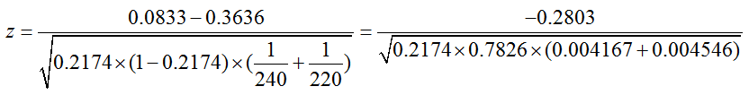

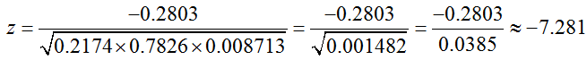

and z<sup>2</sup>=(-7.281)<sup>2</sup>≈ 53 which is approximately the χ<sup>2</sup> value.  
The absolute z-value 7.281 is larger than the critical z<sub>0.05/2</sub>=1.96, so the H<sub>0</sub> is rejected.

Last modified: Monday, 11 March 2019, 8:42 AM